# Practical Machine Learning Course Project

ZMustaqim

October 25, 2015

### Executive Summary

Prediction model been built by investigating different algorithms to the original paper titled “10 repetitions of the Unilateral Dumbbell Biceps Curl in five different fashions”, decision trees and random forests were chosen from the most famous algorithms for classification.

Data cleaning done by removing columns that contained NAs, bad values, zero/near to zero variance or that were irrelevant to the study. This step reduces number of variables to 32 variables that can be used as predictors.

Using decision trees and random forests algorithms have detected the proper features to use for prediction.

Due to time constrain while running the computation, 2 repetitions for the 10-fold and 3-fold repeated cross-validation been used to minimized the computation time.

### Setup

Start with load the required packages to be used in the model later

```r
library(caret)
library(ggplot2)
library(dplyr)
library(rattle)
library(rpart)
library(rpart.plot)
library(randomForest)
```

Loading data set

```r
set.seed(33) # to ensure the result are reproducible
trainingDataRaw = read.csv("pml-training.csv")
testingDataRaw = read.csv("pml-testing.csv")
```

160 variables at this stage

### Data Cleaning

Cleaning training and testing data set by removing: * Column 1 to 7 due to irrelevant * columns with NAs

```r
trainingDataClean = trainingDataRaw[,colSums(is.na(trainingDataRaw)) == 0]
no_use = 1:7
useful = - no_use
trainingDataClean = trainingDataClean[,useful]

testingDataClean = testingDataRaw[,colSums(is.na(testingDataRaw)) == 0]
no_use = 1:7
useful = - no_use
testingDataClean = testingDataClean[,useful]
rm(trainingDataRaw, testingDataRaw, no_use, useful)
```

At this stage:

- training set : 86 variables
- test set : 53 variables

### Data preprocessing

Splitting training dataset into a training set of 75% of the original data and a testing set of the remaining %25. The training portion will be used for training while the second portion is used for adjustments and estimation for out of sample errors.

```r
inTrain = createDataPartition(y=trainingDataClean$classe, p=0.75, list= FALSE)
training = trainingDataClean[inTrain,]
testing = trainingDataClean[-inTrain,]

dim(training); dim(testing)
```

```
## [1] 14718    86
```

```
## [1] 4904   86
```

```r
trainingStep = training # Data Alternative A
trainingStepB = training # Data Alternative B
rm(training, inTrain)
```

At this stage:

- training setA : 86 variables
- training setB : 86 variables
- test set : 53 variables

There are also have variables that have zero or near to zero variance. This variables also will be removed in order to reduce number of possible predictor.

```r
nzv = nearZeroVar(trainingStep, saveMetrics = TRUE)
trainingNZV = trainingStep[, !nzv$zeroVar & !nzv$nzv ]
trainingStep = trainingNZV
dim(trainingNZV)
```

```
## [1] 14718    53
```

```r
rm(nzv, trainingNZV)

nzvB = nearZeroVar(trainingStepB, saveMetrics = TRUE)
trainingNZVB = trainingStepB[, !nzvB$zeroVar & !nzvB$nzv ]
trainingStepB = trainingNZVB
dim(trainingNZVB)
```

```
## [1] 14718    53
```

```r
rm(nzvB, trainingNZVB)
```

At this stage:

- training setA : 53 variables
- training setB : 53 variables
- test set : 53 variables

Also noticed there are variables with highly correlated. This variables also need to be removed to further reduce redundancy and decrease the number of predictors.

```r
trainingTemp = trainingStep[,-53] #Training setA
descrCor <- cor(trainingTemp)
highlyCorrIndices = findCorrelation(descrCor, cutoff = 0.75)
trainingCor = trainingTemp[,-highlyCorrIndices]
trainingCor$classe = trainingStep$classe
trainingStep = trainingCor

trainingTempB = trainingStepB[,-53] #Training setB
descrCorB <- cor(trainingTempB)
highlyCorrIndicesB = findCorrelation(descrCorB, cutoff = 0.75)
trainingCorB = trainingTempB[,-highlyCorrIndicesB]
trainingCorB$classe = trainingStepB$classe
trainingStepB = trainingCorB

rm(trainingCor, trainingCorB, trainingTemp, trainingTempB, descrCor, descrCorB, highlyCorrIndices, highlyCorrIndicesB)
```

At this stage:

- training setA : 33 variables
- training setB : 33 variables
- test set : 53 variables

Then make another 1 more copy for training set for different set of simulation:

- decision trees without cross-validation (Set A)
- decision trees with repeated cross-validation (Set B)
- random forests with reapeated cross-validation. (Set C)

```r
trainingSemifinal = trainingStep # set A
trainingSemifinalB = trainingStepB # Set B
trainingSemifinalC = trainingStepB # Set C

rm(trainingStep, trainingStepB)
```

### Simulation A (Training using decision trees without cross-validation)

Training Process

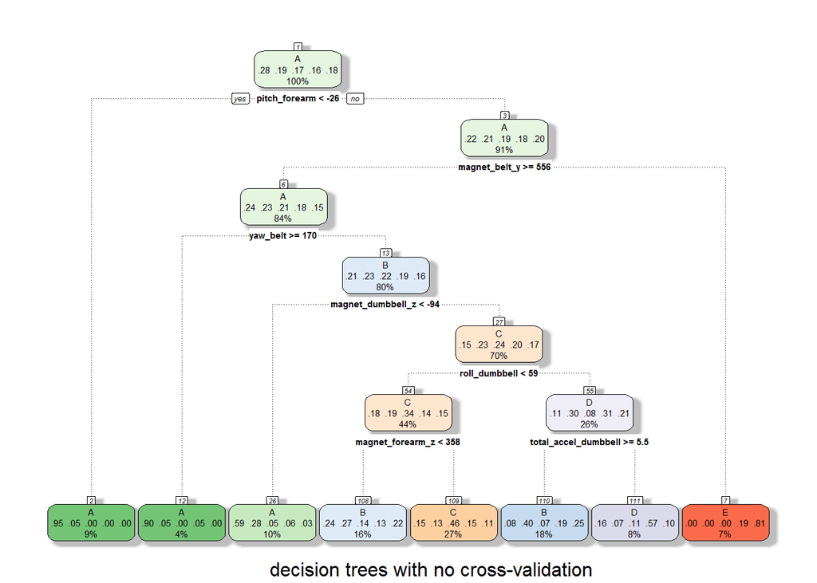

```r
modelFit <- train(classe ~ .,method="rpart",data=trainingSemifinal)
fancyRpartPlot(modelFit$finalModel, sub = "decision trees with no cross-validation")
```

```r
predicted = predict(modelFit, newdata=testing)
confusionMatrix(predicted, testing$classe)
```

```
## Confusion Matrix and Statistics
##
##           Reference
## Prediction   A   B   C   D   E
##          A 886 172  21  42  16
##          B 236 577 183 290 387
##          C 217 174 610 201 156
##          D  55  26  40 208  38
##          E   1   0   1  63 304
##
## Overall Statistics
##
##                Accuracy : 0.5271
##                  95% CI : (0.513, 0.5412)
##     No Information Rate : 0.2845
##     P-Value [Acc > NIR] : < 2.2e-16
##
##                   Kappa : 0.4042
##  Mcnemar's Test P-Value : < 2.2e-16
##
## Statistics by Class:
##
##                      Class: A Class: B Class: C Class: D Class: E
## Sensitivity            0.6351   0.6080   0.7135  0.25871  0.33740
## Specificity            0.9285   0.7229   0.8153  0.96122  0.98376
## Pos Pred Value         0.7792   0.3449   0.4492  0.56676  0.82385
## Neg Pred Value         0.8649   0.8849   0.9309  0.86864  0.86836
## Prevalence             0.2845   0.1935   0.1743  0.16395  0.18373
## Detection Rate         0.1807   0.1177   0.1244  0.04241  0.06199
## Detection Prevalence   0.2319   0.3412   0.2769  0.07484  0.07524
## Balanced Accuracy      0.7818   0.6654   0.7644  0.60996  0.66058
```

Results showing decision trees without cross validation had low accuracy.

### Simulation B (Training using decision trees with 10-fold cross-validation repeated 2 times)

Training Process

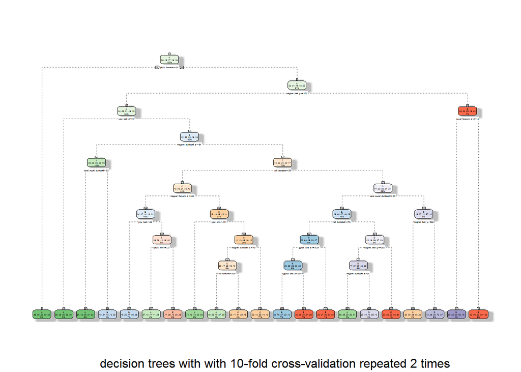

```r
ctrlB = trainControl(method="repeatedcv", number = 10, repeats = 2)
modelFitB <- train(classe ~., data = trainingSemifinalB, method="rpart", tuneLength = 15, trControl=ctrlB)
fancyRpartPlot(modelFitB$finalModel, sub = "decision trees with with 10-fold cross-validation repeated 2 times")
```

```r
predictedB = predict(modelFitB, newdata=testing)
confusionMatrix(predictedB, testing$classe)
```

```
## Confusion Matrix and Statistics
##
##           Reference
## Prediction    A    B    C    D    E
##          A 1140  177   61   45   27
##          B  115  546  116   68   83
##          C   64  109  609  189  164
##          D   48   80   29  433   71
##          E   28   37   40   69  556
##
## Overall Statistics
##
##                Accuracy : 0.6697
##                  95% CI : (0.6563, 0.6828)
##     No Information Rate : 0.2845
##     P-Value [Acc > NIR] : < 2.2e-16
##
##                   Kappa : 0.5816
##  Mcnemar's Test P-Value : < 2.2e-16
##
## Statistics by Class:
##
##                      Class: A Class: B Class: C Class: D Class: E
## Sensitivity            0.8172   0.5753   0.7123   0.5386   0.6171
## Specificity            0.9117   0.9034   0.8701   0.9444   0.9565
## Pos Pred Value         0.7862   0.5884   0.5366   0.6551   0.7616
## Neg Pred Value         0.9262   0.8986   0.9347   0.9126   0.9173
## Prevalence             0.2845   0.1935   0.1743   0.1639   0.1837
## Detection Rate         0.2325   0.1113   0.1242   0.0883   0.1134
## Detection Prevalence   0.2957   0.1892   0.2314   0.1348   0.1489
## Balanced Accuracy      0.8644   0.7394   0.7912   0.7415   0.7868
```

Result showing decision trees with repeated cross-validation had moderate accuracy. Better than simulation A

### Simulation C (Training using random forests with reapeated cross-validation)

Using repated-cv to 3-fold with 2 repetitions

```r
ctrlC = trainControl(method="repeatedcv", number = 3, repeats = 2)
modelFitC <- train(classe ~., data = trainingSemifinalC, method="rf", tuneLength = 2, trControl=ctrlC)
```

```r
predictedC = predict(modelFitC, newdata=testing)
confusionMatrix(predictedC, testing$classe)
```

```
## Confusion Matrix and Statistics
##
##           Reference
## Prediction    A    B    C    D    E
##          A 1395   11    0    0    0
##          B    0  936    5    0    0
##          C    0    2  847   11    0
##          D    0    0    3  792    0
##          E    0    0    0    1  901
##
## Overall Statistics
##
##                Accuracy : 0.9933
##                  95% CI : (0.9906, 0.9954)
##     No Information Rate : 0.2845
##     P-Value [Acc > NIR] : < 2.2e-16
##
##                   Kappa : 0.9915
##  Mcnemar's Test P-Value : NA
##
## Statistics by Class:
##
##                      Class: A Class: B Class: C Class: D Class: E
## Sensitivity            1.0000   0.9863   0.9906   0.9851   1.0000
## Specificity            0.9969   0.9987   0.9968   0.9993   0.9998
## Pos Pred Value         0.9922   0.9947   0.9849   0.9962   0.9989
## Neg Pred Value         1.0000   0.9967   0.9980   0.9971   1.0000
## Prevalence             0.2845   0.1935   0.1743   0.1639   0.1837
## Detection Rate         0.2845   0.1909   0.1727   0.1615   0.1837
## Detection Prevalence   0.2867   0.1919   0.1754   0.1621   0.1839
## Balanced Accuracy      0.9984   0.9925   0.9937   0.9922   0.9999
```

Result showing random forests with repeated cross-validation has the highest accuracy.

Taking simulation C as a final.

### Writing answer to the file

```r
answers = predict(modelFitC, newdata=testingDataClean)
pml_write_files = function(x){
  n = length(x)
  for(i in 1:n){
    filename = paste0("problem_id_",i,".txt")
    write.table(x[i],file=filename,quote=FALSE,row.names=FALSE,col.names=FALSE)
  }
}

pml_write_files(answers)
```

TQ